# suicide_rate_overview

```python
import pandas as pd
import matplotlib.pyplot as plt
import seaborn as sns
import numpy as np
```

```python
df=pd.read_csv('master.csv')
df.head(3)
```

|  | country | year | sex | age | suicides_no | population | suicides/100k pop | country-year | HDI for year | gdp_for_year ($) | gdp_per_capita ($) | generation |
| --- | --- | --- | --- | --- | --- | --- | --- | --- | --- | --- | --- | --- |
| 0 | Albania | 1987 | male | 15-24 years | 21 | 312900 | 6.71 | Albania1987 | NaN | 2,156,624,900 | 796 | Generation X |
| 1 | Albania | 1987 | male | 35-54 years | 16 | 308000 | 5.19 | Albania1987 | NaN | 2,156,624,900 | 796 | Silent |
| 2 | Albania | 1987 | female | 15-24 years | 14 | 289700 | 4.83 | Albania1987 | NaN | 2,156,624,900 | 796 | Generation X |

```python
df.shape
```

```
(27820, 12)
```

```python
df.isna().sum()
```

```
country                   0
year                      0
sex                       0
age                       0
suicides_no               0
population                0
suicides/100k pop         0
country-year              0
HDI for year          19456
 gdp_for_year ($)         0
gdp_per_capita ($)        0
generation                0
dtype: int64
```

```python
df.dtypes
```

[output not shown]

```python
percentage_of_missing_value=((df['HDI for year'].isna().sum())/ len(df)) * 100

round(percentage_of_missing_value,2)
```

```
69.94
```

```python
# dropping the 'HDI for year' column cus almost 70% data are missing, so wont really serve any purpose to the analysis

df.drop('HDI for year', axis=1, inplace=True)
```

```python
df.head()
```

|  | country | year | sex | age | suicides_no | population | suicides/100k pop | country-year | gdp_for_year ($) | gdp_per_capita ($) | generation |
| --- | --- | --- | --- | --- | --- | --- | --- | --- | --- | --- | --- |
| 0 | Albania | 1987 | male | 15-24 years | 21 | 312900 | 6.71 | Albania1987 | 2,156,624,900 | 796 | Generation X |
| 1 | Albania | 1987 | male | 35-54 years | 16 | 308000 | 5.19 | Albania1987 | 2,156,624,900 | 796 | Silent |
| 2 | Albania | 1987 | female | 15-24 years | 14 | 289700 | 4.83 | Albania1987 | 2,156,624,900 | 796 | Generation X |
| 3 | Albania | 1987 | male | 75+ years | 1 | 21800 | 4.59 | Albania1987 | 2,156,624,900 | 796 | G.I. Generation |
| 4 | Albania | 1987 | male | 25-34 years | 9 | 274300 | 3.28 | Albania1987 | 2,156,624,900 | 796 | Boomers |

```python
df.info()
```

```
<class 'pandas.core.frame.DataFrame'>
RangeIndex: 27820 entries, 0 to 27819
Data columns (total 11 columns):
 #   Column              Non-Null Count  Dtype
---  ------              --------------  -----
 0   country             27820 non-null  object
 1   year                27820 non-null  int64
 2   sex                 27820 non-null  object
 3   age                 27820 non-null  object
 4   suicides_no         27820 non-null  int64
 5   population          27820 non-null  int64
 6   suicides/100k pop   27820 non-null  float64
 7   country-year        27820 non-null  object
 8    gdp_for_year ($)   27820 non-null  object
 9   gdp_per_capita ($)  27820 non-null  int64
 10  generation          27820 non-null  object
dtypes: float64(1), int64(4), object(6)
memory usage: 2.3+ MB
```

```python
df.describe()
```

|  | year | suicides_no | population | suicides/100k pop | gdp_per_capita ($) |
| --- | --- | --- | --- | --- | --- |
| count | 27820.000000 | 27820.000000 | 2.782000e+04 | 27820.000000 | 27820.000000 |
| mean | 2001.258375 | 242.574407 | 1.844794e+06 | 12.816097 | 16866.464414 |
| std | 8.469055 | 902.047917 | 3.911779e+06 | 18.961511 | 18887.576472 |
| min | 1985.000000 | 0.000000 | 2.780000e+02 | 0.000000 | 251.000000 |
| 25% | 1995.000000 | 3.000000 | 9.749850e+04 | 0.920000 | 3447.000000 |
| 50% | 2002.000000 | 25.000000 | 4.301500e+05 | 5.990000 | 9372.000000 |
| 75% | 2008.000000 | 131.000000 | 1.486143e+06 | 16.620000 | 24874.000000 |
| max | 2016.000000 | 22338.000000 | 4.380521e+07 | 224.970000 | 126352.000000 |

```python
df.duplicated().sum()
```

```
0
```

```python
def country_column(x):
    print(df[x].unique())
    print('')
    print(f'number of countries: {df[x].nunique()}')
    print('')
    print(f'freuqncy of each {df[x].value_counts()}')

country_column('country')
```

```
['Albania' 'Antigua and Barbuda' 'Argentina' 'Armenia' 'Aruba' 'Australia'
 'Austria' 'Azerbaijan' 'Bahamas' 'Bahrain' 'Barbados' 'Belarus' 'Belgium'
 'Belize' 'Bosnia and Herzegovina' 'Brazil' 'Bulgaria' 'Cabo Verde'
 'Canada' 'Chile' 'Colombia' 'Costa Rica' 'Croatia' 'Cuba' 'Cyprus'
 'Czech Republic' 'Denmark' 'Dominica' 'Ecuador' 'El Salvador' 'Estonia'
 'Fiji' 'Finland' 'France' 'Georgia' 'Germany' 'Greece' 'Grenada'
 'Guatemala' 'Guyana' 'Hungary' 'Iceland' 'Ireland' 'Israel' 'Italy'
 'Jamaica' 'Japan' 'Kazakhstan' 'Kiribati' 'Kuwait' 'Kyrgyzstan' 'Latvia'
 'Lithuania' 'Luxembourg' 'Macau' 'Maldives' 'Malta' 'Mauritius' 'Mexico'
 'Mongolia' 'Montenegro' 'Netherlands' 'New Zealand' 'Nicaragua' 'Norway'
 'Oman' 'Panama' 'Paraguay' 'Philippines' 'Poland' 'Portugal'
 'Puerto Rico' 'Qatar' 'Republic of Korea' 'Romania' 'Russian Federation'
 'Saint Kitts and Nevis' 'Saint Lucia' 'Saint Vincent and Grenadines'
 'San Marino' 'Serbia' 'Seychelles' 'Singapore' 'Slovakia' 'Slovenia'
 'South Africa' 'Spain' 'Sri Lanka' 'Suriname' 'Sweden' 'Switzerland'
 'Thailand' 'Trinidad and Tobago' 'Turkey' 'Turkmenistan' 'Ukraine'
 'United Arab Emirates' 'United Kingdom' 'United States' 'Uruguay'
 'Uzbekistan']

number of countries: 101

freuqncy of each country
Mauritius                 382
Austria                   382
Netherlands               382
Iceland                   382
Brazil                    372
                         ...
Bosnia and Herzegovina     24
Cabo Verde                 12
Dominica                   12
Macau                      12
Mongolia                   10
Name: count, Length: 101, dtype: int64
```

```
sex
male      13910
female    13910
Name: count, dtype: int64
```

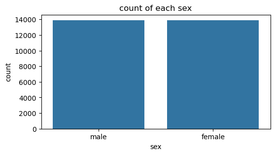

```python
# sex column

def sex_column(x):
    print(df[x].value_counts())

    # visualising
    plt.figure(figsize=(6,3))
    sns.countplot(x=x, data=df)
    plt.title('count of each sex')

sex_column('sex')
# so the sex column is equally distributed
```

```python
df.generation.unique()
```

```
array(['Generation X', 'Silent', 'G.I. Generation', 'Boomers',
       'Millenials', 'Generation Z'], dtype=object)
```

```python
df.year.unique()

# so every  year is covered from 1985-2016
```

```
array([1987, 1988, 1989, 1992, 1993, 1994, 1995, 1996, 1997, 1998, 1999,
       2000, 2001, 2002, 2003, 2004, 2005, 2006, 2007, 2008, 2009, 2010,
       1985, 1986, 1990, 1991, 2012, 2013, 2014, 2015, 2011, 2016],
      dtype=int64)
```

```
age
15-24 years    4642
35-54 years    4642
75+ years      4642
25-34 years    4642
55-74 years    4642
5-14 years     4610
Name: count, dtype: int64
```

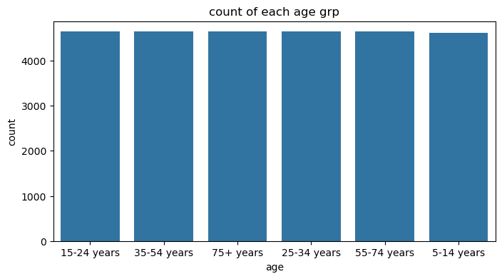

```python
# age column

def AgeGroup_column(x):
    print(df[x].value_counts())

    # visualising
    plt.figure(figsize=(8,4))
    sns.countplot(x=x, data=df)
    plt.title('count of each age grp')

AgeGroup_column('age')
```

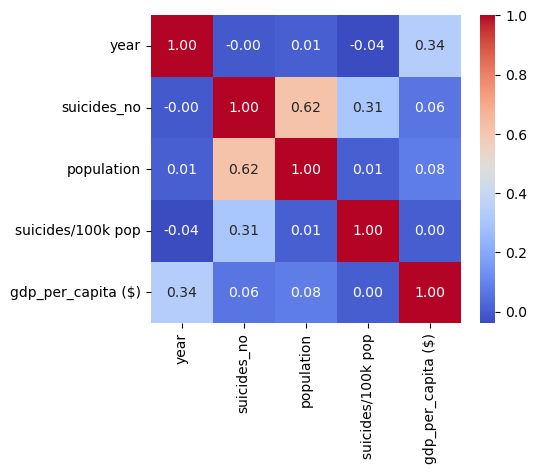

```python
# checking the heatmap of the corr matrix to get a better understanding of the underlying relation between features

numeric_data=df.select_dtypes(include='number')
correlation_matrix=numeric_data.corr()

plt.figure(figsize=(5,4))
sns.heatmap(correlation_matrix, annot=True, fmt='.2f', cmap='coolwarm')
plt.show()
```

```python
df.head()
```

|  | country | year | sex | age | suicides_no | population | suicides/100k pop | country-year | gdp_for_year ($) | gdp_per_capita ($) | generation |
| --- | --- | --- | --- | --- | --- | --- | --- | --- | --- | --- | --- |
| 0 | Albania | 1987 | male | 15-24 years | 21 | 312900 | 6.71 | Albania1987 | 2,156,624,900 | 796 | Generation X |
| 1 | Albania | 1987 | male | 35-54 years | 16 | 308000 | 5.19 | Albania1987 | 2,156,624,900 | 796 | Silent |
| 2 | Albania | 1987 | female | 15-24 years | 14 | 289700 | 4.83 | Albania1987 | 2,156,624,900 | 796 | Generation X |
| 3 | Albania | 1987 | male | 75+ years | 1 | 21800 | 4.59 | Albania1987 | 2,156,624,900 | 796 | G.I. Generation |
| 4 | Albania | 1987 | male | 25-34 years | 9 | 274300 | 3.28 | Albania1987 | 2,156,624,900 | 796 | Boomers |

# which generation commited the most and least suicides??

```
suicide count per generation
Boomers            2284498
Silent             1781744
Generation X       1532804
Millenials          623459
G.I. Generation     510009
Generation Z         15906
Name: suicides_no, dtype: int64
```

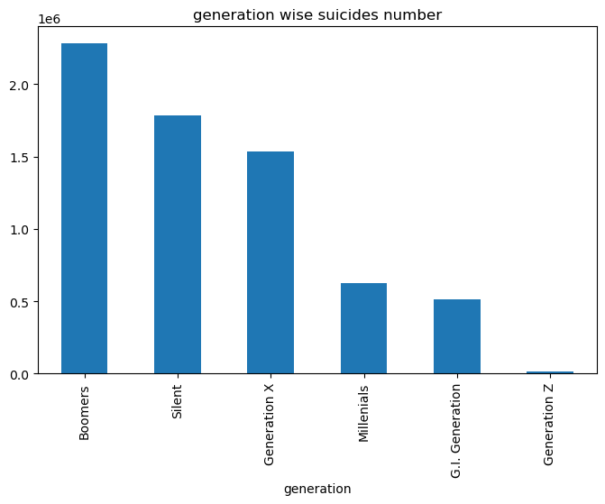

```python
def Generation_column(x):
    suicides_per_gen=df.groupby('generation')['suicides_no'].sum().sort_values(ascending=False)
    print(f'suicide count per {suicides_per_gen}')

    plt.figure(figsize=(8,5))
    suicides_per_gen.plot(kind='bar')
    plt.title('generation wise suicides number')


Generation_column('generation')
```

#### Conclusion: Boomers commited the most suicides and Generation (GenZ) commited the least (as of 2016)

# which year had the most and least number of suicides? also try to find out some other patterns

```
total suicides by year
1985    116063
1986    120670
1987    126842
1988    121026
1989    160244
1990    193361
1991    198020
1992    211473
1993    221565
1994    232063
1995    243544
1996    246725
1997    240745
1998    249591
```

[output cut: 19 more lines]

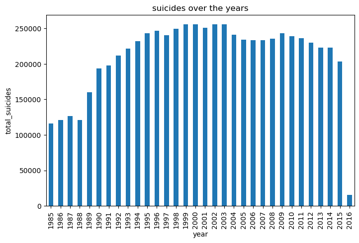

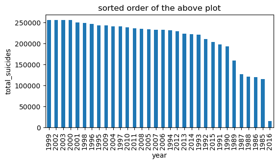

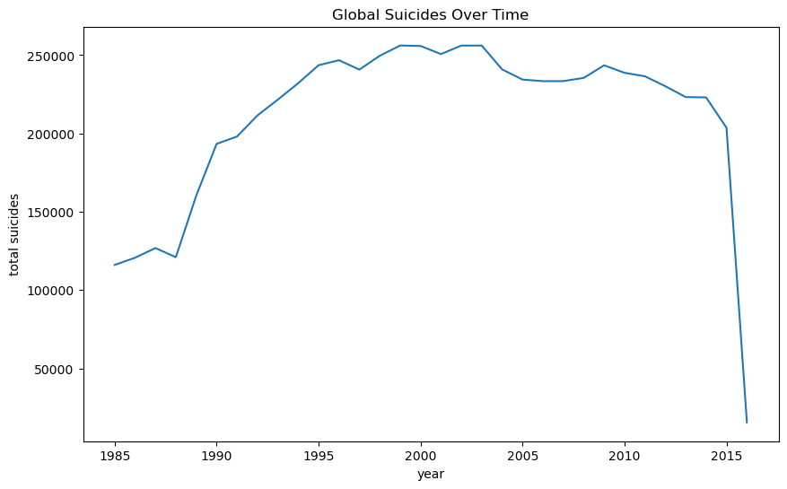

```
So the year 1999 had the most number of suicides of 256119

And the year 2016 had the least number of suicides of 15603 (or atleast upto the time the data was collected)
```

```python
def yearly_total_suicides(x):
    yearly_suicides=df.groupby(x)['suicides_no'].sum()

    print(f'total suicides by {yearly_suicides}')

    # suicides over the years
    plt.figure(figsize=(8,5))
    yearly_suicides.plot(kind='bar')
    plt.title('suicides over the years')
    plt.ylabel('total_suicides')
    plt.show()

    print("")


    # suicides over the years (sorted)
    plt.figure(figsize=(6,3))
    yearly_suicides.sort_values(ascending=False).plot(kind='bar')
    plt.title('sorted order of the above plot')
    plt.ylabel('total_suicides')
    plt.show()


    # global suicides over timne
    plt.figure(figsize=(10, 6))
    sns.lineplot(x='year', y='suicides_no', data=df.groupby('year')['suicides_no'].sum().reset_index())
    plt.title('Global Suicides Over Time')
    plt.ylabel('total suicides')
    plt.show()


    max_suicide_year = yearly_suicides.idxmax() #
    max_suicide_count = yearly_suicides.max()
    min_suicide_year = yearly_suicides.idxmin()
    min_suicide_count = yearly_suicides.min()

    print(f'So the year {max_suicide_year} had the most number of suicides of {max_suicide_count}')
    print('')
    print(f'And the year {min_suicide_year} had the least number of suicides of {min_suicide_count} (or atleast upto the time the data was collected)')

yearly_total_suicides('year')
```

#### Conclusion: 1999 had the most suicides and 2016 had the least. Also, the suicides peaked 1989 onwards and showing a gradual sign of descent 2010 onwards

# which sex commited the most number of suicides??

```
total number of suicides by sex
female    1559510
male      5188910
Name: suicides_no, dtype: int64
```

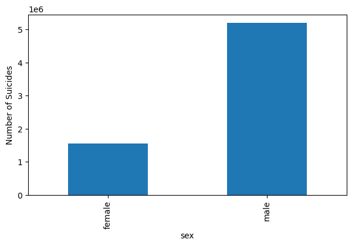

```python
def sex_wise_suicides(x):
    total_suicides_by_sex=df.groupby(x)['suicides_no'].sum()

    print(f'total number of suicides by {total_suicides_by_sex}')

    print('')

    plt.figure(figsize=(7,4))
    df.groupby('sex')['suicides_no'].sum().plot(kind='bar')
    plt.ylabel('Number of Suicides')
    plt.show()

sex_wise_suicides('sex')
```

#### Conclusion: Men commited the most number of suicides

# which country had the most number of suicide cases??

```
total suicides by country
Russian Federation       1209742
United States            1034013
Japan                     806902
France                    329127
Ukraine                   319950
                          ...
Maldives                      20
Antigua and Barbuda           11
San Marino                     4
Saint Kitts and Nevis          0
Dominica                       0
Name: suicides_no, Length: 101, dtype: int64
```

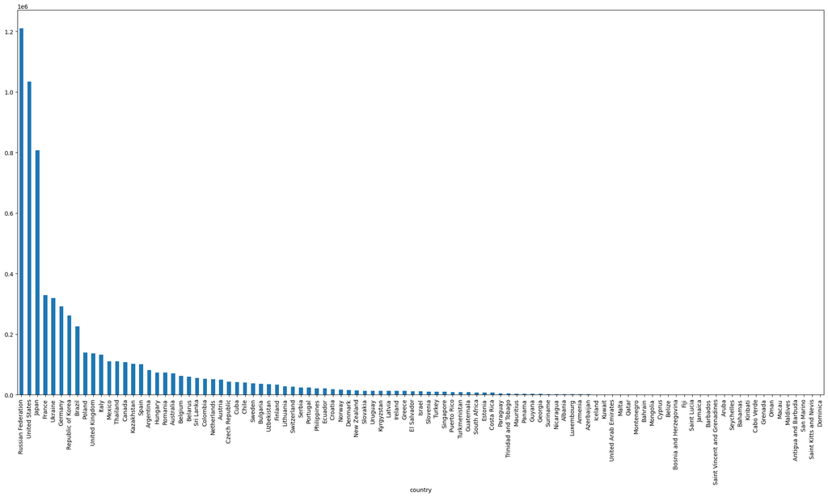

```
So the country Russian Federation had the most number of suicides of 1209742

And the country Saint Kitts and Nevis had the most number of suicides of 0 (or atleast upto the time the data was collected)
```

```python
def country_wise_total_suicides(x):
    countries_by_suicide=df.groupby(x)['suicides_no'].sum().sort_values(ascending=False)
    print(f'total suicides by {countries_by_suicide}')


    plt.figure(figsize=(25,12))
    countries_by_suicide.plot(kind='bar')
    plt.show()



    max_suicide_country = countries_by_suicide.idxmax()  # getting the index of the max value
    max_suicide_country_count = countries_by_suicide.max()
    min_suicide_country = countries_by_suicide.idxmin()  # getting the index of the min value
    min_suicide_country_count = countries_by_suicide.min()

    print('')
    print('')

    print(f'So the country {max_suicide_country} had the most number of suicides of {max_suicide_country_count}')
    print("")
    print(f'And the country {min_suicide_country} had the most number of suicides of {min_suicide_country_count} (or atleast upto the time the data was collected)')


country_wise_total_suicides('country')
```

#### Conclusion: Russia had the most number of suicide case whereas Saint Kitts and Nevis and Dominica had literally 0 suicides and other than these two, San Marino takes the next spot with only 4 suicides